# OSM history data : first analysis with R

# Introduction: data loading and preparation

This R notebook is dedicated to the presentation of a small OSM data extraction, considering the French city of Bordeaux. To have a little bit more information about R markdown notebooks, do not hesitate to follow [this link](http://rmarkdown.rstudio.com).

Here we start from the OSM data history, and more precisely with 3 .csv files extracted from a .pbf file, with the help of the [osmium Python library](https://github.com/osmcode/pyosmium). These 3 files contain histories respectively dedicated to nodes, ways and relations.

First we load them into the workspace:

```r
print(getwd()) # print the working directory path
```

```
[1] "/home/rde/Documents/osland-ia/demo"
```

```r
tlnodes = read.csv("~/data/bordeaux-metropole/latest-bordeaux-metropole-node-timeline.csv",stringsAsFactors = F)
tlways = read.csv("~/data/bordeaux-metropole/latest-bordeaux-metropole-way-timeline.csv",stringsAsFactors = F)
tlrelations = read.csv("~/data/bordeaux-metropole/latest-bordeaux-metropole-relation-timeline.csv",stringsAsFactors = F)
```

For a sake of convenience, we transform the timestamp information into a dedicated R format for dates:

```r
tlnodes$ts = as.POSIXct(tlnodes$ts)
tlways$ts = as.POSIXct(tlways$ts)
tlrelations$ts = as.POSIXct(tlrelations$ts)
```

By the way we are able to recover the updated information on nodes, ways and relations starting from these history files with the following function:

```r
updatedelem = function(data){
  # Recover last version of elements (nodes, ways or relations)
  upddata = aggregate(version~id , data=data , FUN=max)
  upddata = merge(data,upddata)
  upddata = upddata[order(upddata$id),]
}
nodes = updatedelem(tlnodes)
ways = updatedelem(tlways)
relations = updatedelem(tlrelations)
```

# Main treatments

## First: build a generic data.frame containing every modifications on elements

Noting that each OSM element has a set of common parameter *(id, version, contributor, change set, timestamp, tags)*, we can group all these records, before further data processing.

```r
useractivity = cbind(elem=rep("n",nrow(tlnodes)),tlnodes[,c("id","version","uid","chgset","ts","ntags")])
useractivity = rbind( useractivity , cbind(elem=rep("w",nrow(tlways)),tlways[,c("id","version","uid","chgset","ts","ntags")]) )
useractivity = rbind( useractivity , cbind(elem=rep("r",nrow(tlrelations)),tlrelations[,c("id","version","uid","chgset","ts","ntags")]) )
useractivity = useractivity[order(useractivity$ts),]
```

The *useractivity* structure gather the good part of OSM metadata.

## Element description

The first crucial structure that we can build is dedicated to the OSM elements. Here we will mix nodes, ways and relations, to investigate on their associated metadata. Let’s consider the number of unique contributors per element, the number of versions (how many time is an element updated?) and some information regarding the *life cycle* of elements.

### Analyse 1: how many unique user per elements

By aggregating the user IDs for each element (a type -node, way or relation- and an ID), we can compute the number of unique contributors.

```r
userbyelem = aggregate(uid~elem+id,data=useractivity,FUN=function(x){length(unique(x))})
```

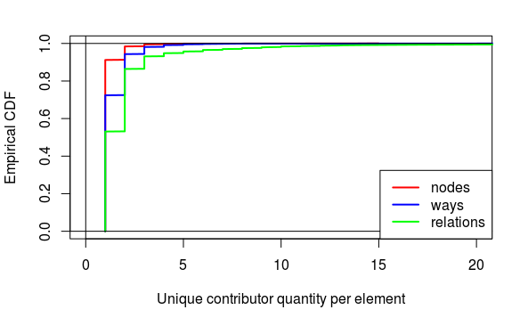

### Analyse 2: how many version per elements

The elements are also characterized by a version number, that represents the number of updates. With a similar aggregation procedure, we can easily extract this feature. We choose the function *length* in the following code, however *max* would have been equivalent, as the version is trivially incremented at each update.

```r
versionbyelem = aggregate(version~elem+id,data=useractivity,length)
```

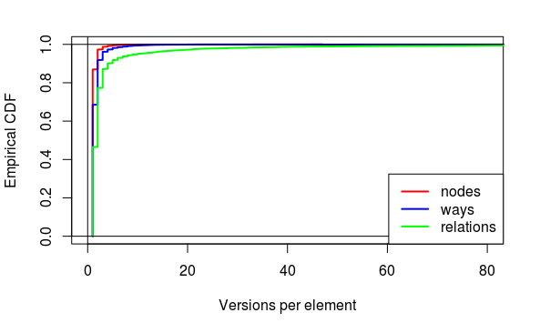

Here we can see that the proportion of elements with 2 versions are quite similar to the corresponding percentage for unique contributors, even if the values are smaller. However the shift between each type of element seems more important, and the quantity of version that covers 100% of element is greater (around 60) : relations, that are much more complex structures, are longer to design.

By merging the results of both analysis, we have a base for our element dataset. We can remove the intermediary variable to keep the workspace as clean as possible.

```r
elemsynthesis = merge(userbyelem,versionbyelem)
remove(userbyelem,versionbyelem)
```

We can plot these information together to try to understand if there is any evident pattern in element building.

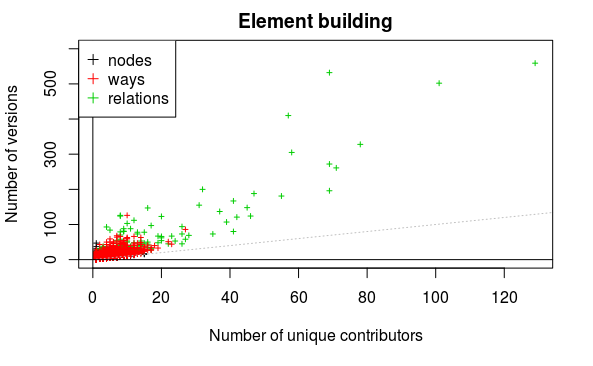

According to this plot, most elements are characterized with less than 15 unique contributors and less than 60 versions. That confirm the previous information. There is no real difference between each type of element, however we can notice that there are some outliers amongst relations: some of them have needed tens of contributors and have been updated hundreds of time.

### Analyse 3 : temporal description of element life cycle

After user and version analysis, we can spend a little bit time on element temporal evolution. With the same aggregation process, we can easily find the first and the last updates, by using *min* and *max* functions on modification timestamps. We merge these information to *elemsynthesis* dataframe to complete it.

```r
elembegin = setNames(aggregate(ts~elem+id , useractivity , min),c("elem","id","creation"))
elemend = setNames(aggregate(ts~elem+id , useractivity , max),c("elem","id","lastmodif"))
elemsynthesis = merge( elemsynthesis , elembegin )
elemsynthesis = merge( elemsynthesis , elemend )
remove(elembegin,elemend)
```

We can evaluate the difference between both dates by creating a new feature *lifecycle*, which gives, in days, the period during which the element updates have been done.

```r
elemsynthesis$lifecycle = apply(elemsynthesis , 1 , function(x){round(difftime(x[["lastmodif"]] , x[["creation"]] , units="days")[[1]],2)})
```

To focus more on this life cycle concept, we can distinguish between deleted elements (nodes with unknown coordinates, ways without any nodes, relations with any members) and elements that are still available.

```r
elemsynthesis$available = rep(T,nrow(elemsynthesis))
delnodes = nodes[nodes$lon==Inf,"id"]
delways = ways[ways$nnodes==0,"id"]
delrelations = relations[relations$nmembers==0,"id"]
elemsynthesis[elemsynthesis$elem=="n"&elemsynthesis$id%in%delnodes,"available"] = F
elemsynthesis[elemsynthesis$elem=="w"&elemsynthesis$id%in%delways,"available"] = F
elemsynthesis[elemsynthesis$elem=="r"&elemsynthesis$id%in%delrelations,"available"] = F
remove(delnodes,delways,delrelations)
```

This availability feature helps us to change the definition of *lifecycle* variable: by definition, an available element do not have ended its life cycle, we have to update it consequently. We use the date of extraction in this purpose.

```r
timehorizon = as.POSIXct("2017-02-13 0:00:00") # date of OSM data extraction
elemsynthesis[elemsynthesis$available,"lifecycle"] = apply(elemsynthesis[elemsynthesis$available,] , 1 , function(x){round(difftime(timehorizon , x[["creation"]] , units="days")[[1]],2)})
```

### conclusion: description of OSM elements

```r
names(elemsynthesis) = c("type","id","nuniqcontrib","nversion","creation","lastmodif","lifecycle.days","available")
summary(elemsynthesis)
```

```
 type              id             nuniqcontrib        nversion
 n:2352135   Min.   :2.986e+03   Min.   :  1.000   Min.   :   1.000
 w: 403279   1st Qu.:1.165e+09   1st Qu.:  1.000   1st Qu.:   1.000
 r:   5333   Median :1.682e+09   Median :  1.000   Median :   1.000
             Mean   :1.559e+09   Mean   :  1.149   Mean   :   1.253
             3rd Qu.:1.946e+09   3rd Qu.:  1.000   3rd Qu.:   1.000
             Max.   :4.682e+09   Max.   :129.000   Max.   :2031.000
    creation                     lastmodif                   lifecycle.days
 Min.   :2007-01-14 01:37:52   Min.   :2007-04-30 17:07:54   Min.   :   0
 1st Qu.:2011-12-04 11:16:26   1st Qu.:2012-03-09 20:51:27   1st Qu.:1357
 Median :2012-04-13 05:14:32   Median :2012-05-13 18:10:09   Median :1736
 Mean   :2012-05-13 20:36:50   Mean   :2012-08-16 02:56:52   Mean   :1605
 3rd Qu.:2012-11-20 18:15:15   3rd Qu.:2013-04-24 19:03:04   3rd Qu.:1801
 Max.   :2017-02-12 19:27:59   Max.   :2017-02-12 22:14:20   Max.   :3683
 available
 Mode :logical
 FALSE:213463
 TRUE :2547284
 NA's :0
```

```r
kable(head(elemsynthesis))
```

| type | id | nuniqcontrib | nversion | creation | lastmodif | lifecycle.days | available |
| --- | --- | --- | --- | --- | --- | --- | --- |
| n | 1000009143 | 1 | 1 | 2010-11-22 20:18:36 | 2010-11-22 20:18:36 | 2274.15 | TRUE |
| n | 1000009157 | 1 | 1 | 2010-11-22 20:18:36 | 2010-11-22 20:18:36 | 2274.15 | TRUE |
| n | 1000009159 | 1 | 1 | 2010-11-22 20:18:36 | 2010-11-22 20:18:36 | 2274.15 | TRUE |
| n | 1000009162 | 1 | 1 | 2010-11-22 20:18:36 | 2010-11-22 20:18:36 | 2274.15 | TRUE |
| n | 1000010863 | 1 | 1 | 2010-11-22 20:21:26 | 2010-11-22 20:21:26 | 2274.15 | TRUE |
| n | 1000010864 | 1 | 1 | 2010-11-22 20:21:26 | 2010-11-22 20:21:26 | 2274.15 | TRUE |

## Change set metadata

On the model of element-oriented treatments, we want to continue the metadata study by focusing on OSM change sets. This structure gathers a bunch of modifications realized by a contributor in a limited time. We may investigate on the number of changes in each change set, as well as on their duration.

#### Analyse 4: how many modifications per change set

By definition, the [OSM change sets]{https://wiki.openstreetmap.org/wiki/Changeset} can include until 10000 modifications. However in standard OSM contributions, this limit is rarely reached.

To compute the number of modifications done in each change sets, we reuse the *aggregate* procedure with the *length* function.

```r
modifbychgset = aggregate(cbind(elem,id)~chgset , data=useractivity, FUN=length)
modifbychgset = merge(modifbychgset[,-3] , unique(useractivity[,c("chgset","uid")]))[,c(1,3,2)]
```

We can consequently plot the empirical cumulative distribution function describing how many modifications may be expected in a typical change set:

```r
plot(quantile(modifbychgset$elem,probs=seq(0,1,0.001)),seq(0,1,0.001),type="l",col="red",lwd=2,xlim=c(0,200),xlab="Modification quantity per change set",ylab="Empirical CDF")
abline(h=c(0,1),v=0)
```

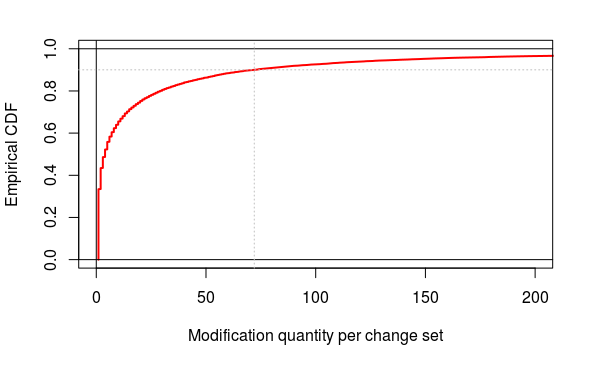

```r
abline(h=0.9,lty="dotted",col="grey")
abline(v=quantile(modifbychgset$elem,probs=0.9),lty="dotted",col="grey")
```

We can go deeper into this analysis by differentiating element types.

```r
nodemodifbychgset = setNames(aggregate(id~chgset , data=useractivity[useractivity$elem=="n",], FUN=length),c("chgset","nnodemodif"))
waymodifbychgset = setNames(aggregate(id~chgset , data=useractivity[useractivity$elem=="w",], FUN=length),c("chgset","nwaymodif"))
relationmodifbychgset = setNames(aggregate(id~chgset , data=useractivity[useractivity$elem=="r",], FUN=length),c("chgset","nrelationmodif"))
```

The difference between elements can be showed graphically, still with a CDF-focused analysis.

```r
plot(quantile(nodemodifbychgset$nnodemodif,probs=seq(0,1,0.001)),seq(0,1,0.001),type="l",col="red",lwd=2,xlim=c(0,100),xlab="Modification per change set",ylab="Empirical CDF")
lines(quantile(waymodifbychgset$nwaymodif,probs=seq(0,1,0.001)),seq(0,1,0.001),col="blue",lwd=2)
```

```r
lines(quantile(relationmodifbychgset$nrelationmodif,probs=seq(0,1,0.001)),seq(0,1,0.001),col="green",lwd=2)
abline(h=c(0,1),v=0)
```

```r
abline(h=0.9,lty="dotted",col="grey")
abline(v=quantile(nodemodifbychgset$nnodemodif,probs=0.9),lty="dotted",col="grey")
```

```r
abline(v=quantile(waymodifbychgset$nwaymodif,probs=0.9),lty="dotted",col="grey")
abline(v=quantile(relationmodifbychgset$nrelationmodif,probs=0.9),lty="dotted",col="grey")
```

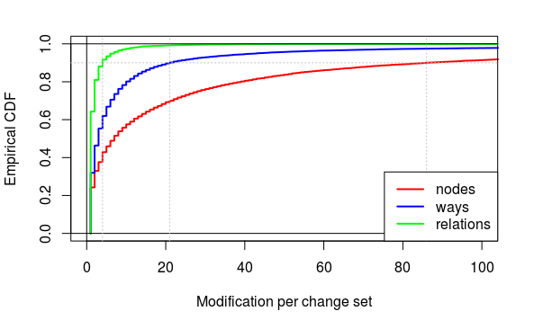

```r
legend("bottomright",legend=c("nodes","ways","relations"),col=c("red","blue","green"),lwd=2)
```

With this first analysis, we can build the change set dataframe, and remove the useless structures.

```r
chgsetsynthesis = merge(modifbychgset,nodemodifbychgset,all=T)
chgsetsynthesis = merge(chgsetsynthesis,waymodifbychgset,all=T)
chgsetsynthesis = merge(chgsetsynthesis,relationmodifbychgset,all=T)
remove(nodemodifbychgset,waymodifbychgset,relationmodifbychgset)
```

### Analyse 5: temporal description of change sets

By addition with the last study, a focus has to be done on the change set temporal characterization. Like elements, we have two seminal features to extract: the change set beginning and its end. For the moment we do not have the real information, so we consider the first modification (respectively the last) as the change set beginning (respectively the end). Consequently the change set duration is computed as the difference (in minutes) between these two milestones. The maximal duration is 24 hours, by definition (see [wiki]{https://wiki.openstreetmap.org/wiki/Changeset}).

```r
chgsetbegin = setNames(aggregate(ts~chgset , useractivity , min),c("chgset","begin"))
chgsetend = setNames(aggregate(ts~chgset , useractivity , max),c("chgset","end"))
chgsetsynthesis = merge( chgsetsynthesis , chgsetbegin , all=T )
chgsetsynthesis = merge( chgsetsynthesis , chgsetend , all=T )
chgsetsynthesis$duration = apply(chgsetsynthesis , 1 , function(x){round(difftime(x[["end"]] , x[["begin"]] , units="min")[[1]],2)})
```

We can plot this last information, for example by crossing it with respect to the number of node modification.

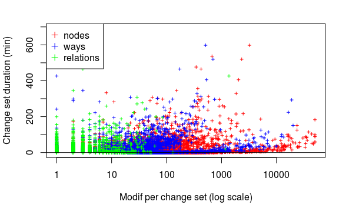

The duration of a change set does not seem to be related with the number of modifications. **[Problem: less than 10000 modifications by definition, but node and way modification quantities are higher…]**

### conclusion: description of OSM change sets

```r
names(chgsetsynthesis) = c("chgset","uid","nmodif","nnodemodif","nwaymodif","nrelationmodif","begin","end","duration.min")
summary(chgsetsynthesis)
```

```
     chgset              uid              nmodif          nnodemodif
 Min.   :    3649   Min.   :    165   Min.   :    1.0   Min.   :    1.0
 1st Qu.:10439842   1st Qu.:  53921   1st Qu.:    1.0   1st Qu.:    2.0
 Median :19644023   Median : 302591   Median :    4.0   Median :    7.0
 Mean   :21335367   Mean   : 849709   Mean   :  101.1   Mean   :  122.6
 3rd Qu.:33149713   3rd Qu.:1309032   3rd Qu.:   20.0   3rd Qu.:   28.0
 Max.   :46031817   Max.   :5296022   Max.   :50000.0   Max.   :50000.0
                                                        NA's   :11318
   nwaymodif        nrelationmodif         begin
 Min.   :    1.00   Min.   :   1.000   Min.   :2007-01-14 01:37:52
 1st Qu.:    1.00   1st Qu.:   1.000   1st Qu.:2012-01-19 18:31:39
 Median :    3.00   Median :   1.000   Median :2013-12-26 13:29:46
 Mean   :   29.69   Mean   :   2.514   Mean   :2013-08-24 11:06:42
 3rd Qu.:    8.00   3rd Qu.:   2.000   3rd Qu.:2015-08-06 09:06:12
 Max.   :20001.00   Max.   :1363.000   Max.   :2017-02-12 22:13:28
 NA's   :13118      NA's   :24698
      end                       duration.min
 Min.   :2007-01-14 01:46:10   Min.   :  0.000
 1st Qu.:2012-01-19 18:31:39   1st Qu.:  0.000
 Median :2013-12-26 14:21:26   Median :  0.020
 Mean   :2013-08-24 11:09:51   Mean   :  3.146
 3rd Qu.:2015-08-06 09:06:13   3rd Qu.:  0.070
 Max.   :2017-02-12 22:14:20   Max.   :690.320
```

```r
kable(head(chgsetsynthesis))
```

| chgset | uid | nmodif | nnodemodif | nwaymodif | nrelationmodif | begin | end | duration.min |
| --- | --- | --- | --- | --- | --- | --- | --- | --- |
| 3649 | 54026 | 8 | 3 | 5 | NA | 2008-08-01 00:49:17 | 2008-08-01 00:49:49 | 0.53 |
| 4562 | 50104 | 414 | 381 | 33 | NA | 2008-08-01 00:46:51 | 2008-08-01 01:31:32 | 44.68 |
| 4883 | 54026 | 1427 | 1124 | 303 | NA | 2008-08-01 08:17:27 | 2008-08-01 12:31:59 | 254.53 |
| 4890 | 29316 | 112 | 68 | 44 | NA | 2008-04-01 10:17:32 | 2008-04-01 11:20:29 | 62.95 |
| 5162 | 50104 | 30 | 28 | 2 | NA | 2008-08-01 12:41:44 | 2008-08-01 13:13:47 | 32.05 |
| 5298 | 54026 | 12 | 10 | 2 | NA | 2008-08-01 13:32:22 | 2008-08-01 13:33:59 | 1.62 |

## User metadata

After elements and change sets, we can check the user metadata. Several questions arise if we want to produce a first insight of this dimension. How many contributions do the users produce ? How many change sets do they open ? How many modifications do they make on unique elements ? And like previously, have we got experienced users with contributions during several years, or are there more one-shot users ?

### Analyse 6: number of contributions

First we can investigate on the number of contributions that each user has produced. These contributions are simply the number of modifications done on elements. All modifications are grouped by change sets.

Consequently we apply the aggregation function just as previously to gather the number of change sets opened by each users.

```r
chgsetbyuser = aggregate(chgset~uid,data=modifbychgset,FUN=length)
```

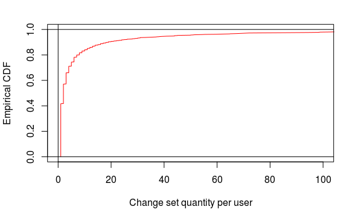

It seems that around 40% are one-shot users (only one change set), however there are very experienced users too: we have to reached 100 change sets to capture almost all individuals. 90% of users open less than 20 change sets.

A more precise point can be supplied by the modification level. If we aggregate the number of modifications done by each users, we have the following figure:

```r
modifbyuser = aggregate(cbind(elem,id)~uid , data=useractivity, FUN=length)[,-3]
```

```r
plot(quantile(modifbychgset$elem,probs=seq(0,1,0.001)),seq(0,1,0.001),type="l",col="red",lwd=2,xlim=c(0,100),xlab="Total modification per user",ylab="Empirical CDF")
abline(h=c(0,1),v=0)
```

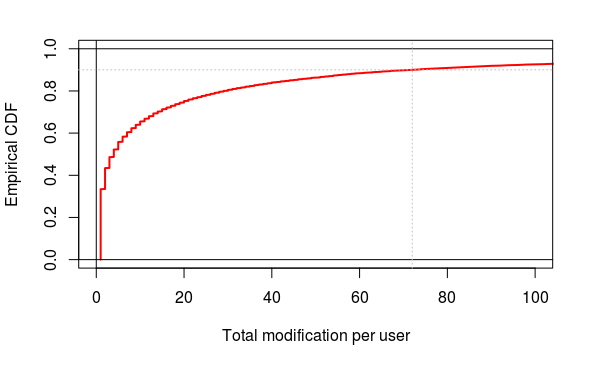

```r
abline(h=0.9,lty="dotted",col="grey")
abline(v=quantile(modifbychgset$elem,probs=0.9),lty="dotted",col="grey")
```

We can build the future user dataframe by gathering both features.

```r
usersynthesis = merge(chgsetbyuser,modifbyuser)
remove(chgsetbyuser,modifbyuser)
```

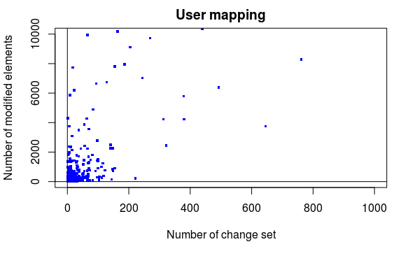

By plotting both information (number of change sets on the first hand and number of modifications on the second hand), we can see that there is no particular pattern. Of course, some productive users exist (high numbers of change sets and modifications), however they are kind of outliers in our database…

How many modification have the users produce on each element type? The answer to this question could bring more precision of the previous analysis. Consequently we re-aggregate modifications for each users, by discriminating each element type.

```r
nodemodifperuser = setNames(aggregate(id~uid , data=useractivity[useractivity$elem=="n",], FUN=length),c("uid","nnodemodif"))
waymodifperuser = setNames(aggregate(id~uid , data=useractivity[useractivity$elem=="w",], FUN=length),c("uid","nwaymodif"))
relationmodifperuser = setNames(aggregate(id~uid , data=useractivity[useractivity$elem=="r",], FUN=length),c("uid","nrelationmodif"))
```

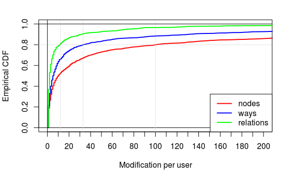

Like for previous structures, we can end the user dataframe by merging all these features.

```r
usersynthesis = merge(usersynthesis,nodemodifperuser,all=T)
usersynthesis = merge(usersynthesis,waymodifperuser,all=T)
usersynthesis = merge(usersynthesis,relationmodifperuser,all=T)
remove(nodemodifperuser,waymodifperuser,relationmodifperuser)
```

# Analyse 7 : temporal description of user contributions

If we analyse the user activity in a chronological point of view, we can recover the first and last contributions, and consequently the user longevity as OSM contributors (in days).

```r
userfirst = setNames(aggregate(ts~uid , useractivity , min),c("uid","first"))
userlast = setNames(aggregate(ts~uid , useractivity , max),c("uid","last"))
usersynthesis = merge( usersynthesis , userfirst , all=T )
usersynthesis = merge( usersynthesis , userlast , all=T )
usersynthesis$activity.days = apply(usersynthesis , 1 , function(x){round(difftime(x[["last"]] , x[["first"]] , units="days")[[1]],2)})
```

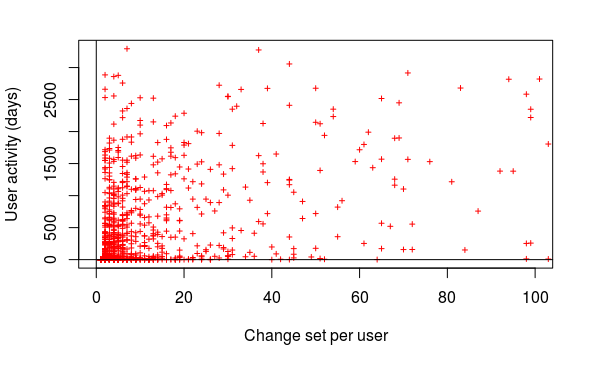

An exemple of graphical analysis in this direction is the comparison between user longevity and the number of change sets that the users open. One-shot users represent in the bottom-left of the figure, with one single change and a longevity of 0 days (first and last timestamp are equal). Like previously, no clear pattern exist between both features in terms of linear relationship. We have a confirmation about the relative low number of change set open by users. Additionnally, we can see that there are not so many users that are active years after years (this point has to be shaded by the fact that we are focused on a small geographical area here).

### conclusion: description of OSM contributors

```r
names(usersynthesis) = c("uid","nchgset","nmodif","nnodemodif","nwaymodif","nrelationmodif","first","last","activity.days")
summary(usersynthesis)
```

```
      uid             nchgset            nmodif         nnodemodif
 Min.   :    165   Min.   :   1.00   Min.   :     1   Min.   :     1.0
 1st Qu.: 133876   1st Qu.:   1.00   1st Qu.:     2   1st Qu.:     2.0
 Median : 570658   Median :   2.00   Median :     5   Median :    10.0
 Mean   :1209085   Mean   :  16.56   Mean   :  1674   Mean   :  2150.2
 3rd Qu.:2012124   3rd Qu.:   6.00   3rd Qu.:    36   3rd Qu.:    59.8
 Max.   :5296022   Max.   :4428.00   Max.   :644338   Max.   :547169.0
                                                      NA's   :760
   nwaymodif       nrelationmodif        first
 Min.   :    1.0   Min.   :   1.00   Min.   :2007-01-14 01:37:52
 1st Qu.:    2.0   1st Qu.:   1.00   1st Qu.:2011-05-16 16:49:22
 Median :    5.0   Median :   2.00   Median :2013-07-06 07:16:17
 Mean   :  546.5   Mean   :  25.21   Mean   :2013-04-06 21:53:10
 3rd Qu.:   21.0   3rd Qu.:   7.00   3rd Qu.:2015-06-02 08:36:13
 Max.   :96935.0   Max.   :3563.00   Max.   :2017-02-11 18:58:45
 NA's   :920       NA's   :1117
      last                     activity.days
 Min.   :2007-03-21 10:20:33   Min.   :   0.00
 1st Qu.:2012-04-07 21:17:43   1st Qu.:   0.00
 Median :2014-06-13 18:25:07   Median :   0.02
 Mean   :2013-12-21 17:56:03   Mean   : 258.88
 3rd Qu.:2016-02-26 18:33:52   3rd Qu.: 160.47
 Max.   :2017-02-12 22:14:20   Max.   :3293.48
```

```r
kable(head(usersynthesis))
```

| uid | nchgset | nmodif | nnodemodif | nwaymodif | nrelationmodif | first | last | activity.days |
| --- | --- | --- | --- | --- | --- | --- | --- | --- |
| 165 | 2 | 2 | NA | NA | 2 | 2012-02-27 20:30:40 | 2012-03-13 09:47:25 | 14.55 |
| 356 | 2 | 12 | 7 | 3 | 2 | 2012-08-05 09:08:20 | 2012-08-06 09:28:32 | 1.01 |
| 364 | 1 | 1 | NA | NA | 1 | 2011-06-11 16:16:01 | 2011-06-11 16:16:01 | 0.00 |
| 508 | 3 | 582 | 576 | 6 | NA | 2007-10-24 12:51:31 | 2007-10-24 21:26:07 | 0.36 |
| 578 | 1 | 1 | NA | NA | 1 | 2009-05-05 13:52:02 | 2009-05-05 13:52:02 | 0.00 |
| 653 | 1 | 1 | NA | NA | 1 | 2015-04-20 16:08:07 | 2015-04-20 16:08:07 | 0.00 |

# Last but not least: let’s conclude !

## Saving built structures

Each important data structure evoked in this notebook has to be saved, to allow an eventual reuse later…

```r
# The image of the R session in a .RData file...
save.image("../data/bordeaux-metropole.RData")
```

[output not shown]

[output not shown]

## To go further

- analyse of tags (types of ways, nodes, relations)
- reproduction on a larger scale (a French area, like Rhône-Alpes or Aquitaine for example)